# Arrival and Departure Final Models with Traits Included: EXCLUDING AI, GOA, WCTRI; NO SLEEPER

This is a cleaned version of dredge_trait_models Changes

- species and region as random effects (not year)
- scaling temperature values
- setting nACQ to 0, see why [here](https://stats.stackexchange.com/questions/77313/why-cant-i-match-glmer-family-binomial-output-with-manual-implementation-of-g).

```r
library(MuMIn)
library(lme4)
library(data.table)
library(ggplot2)
library(plyr)

spp_master_ztemp_seus_buoy.traits_scaled <- readRDS(here::here("Data","Spp_master","spp_master_ztemp_seus_buoy.traits_scaled.rds"))

spp_master_ztemp_seus_buoy_scaled <- readRDS(here::here("Data","Spp_master","spp_master_ztemp_seus_buoy_scaled.rds"))
```

I will be looking at:

*trophic level* maximum age *age at maturity* maximum body size

```r
summary(spp_master_ztemp_seus_buoy.traits_scaled$age.max) #702 missing
```

```
Length  Class   Mode
     0   NULL   NULL
```

```r
summary(spp_master_ztemp_seus_buoy.traits_scaled$age.maturity) #551 missing
```

```
Length  Class   Mode
     0   NULL   NULL
```

```r
summary(spp_master_ztemp_seus_buoy.traits_scaled$tl) #none missing
```

```
Length  Class   Mode
     0   NULL   NULL
```

```r
summary(spp_master_ztemp_seus_buoy.traits_scaled$length.max) #none missing
```

```
Length  Class   Mode
     0   NULL   NULL
```

```r
summary(spp_master_ztemp_seus_buoy.traits_scaled$length.infinity) #443 missing, this is highly correlated (0.82) with length max, so we'll just use length.max
```

```
Length  Class   Mode
     0   NULL   NULL
```

```r
cor(spp_master_ztemp_seus_buoy.traits_scaled[,.(age.max_ocean_scaled, age.maturity_ocean_scaled, tl_ocean_scaled, length.max_ocean_scaled)], use = "complete.obs")
```

```
                          age.max_ocean_scaled age.maturity_ocean_scaled tl_ocean_scaled
age.max_ocean_scaled                 1.0000000                 0.6303575       0.1861977
age.maturity_ocean_scaled            0.6303575                 1.0000000       0.1329661
tl_ocean_scaled                      0.1861977                 0.1329661       1.0000000
length.max_ocean_scaled              0.4432706                 0.5627943       0.3606692
                          length.max_ocean_scaled
age.max_ocean_scaled                    0.4432706
age.maturity_ocean_scaled               0.5627943
tl_ocean_scaled                         0.3606692
length.max_ocean_scaled                 1.0000000
```

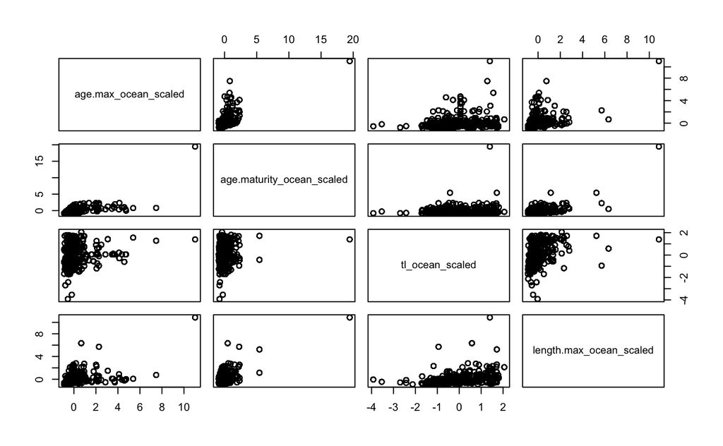

```r
pairs(spp_master_ztemp_seus_buoy.traits_scaled[,.(age.max_ocean_scaled, age.maturity_ocean_scaled, tl_ocean_scaled, length.max_ocean_scaled)])
```

What’s the distribution of trait values?

```
Warning: Removed 26 rows containing non-finite values (stat_bin).
```

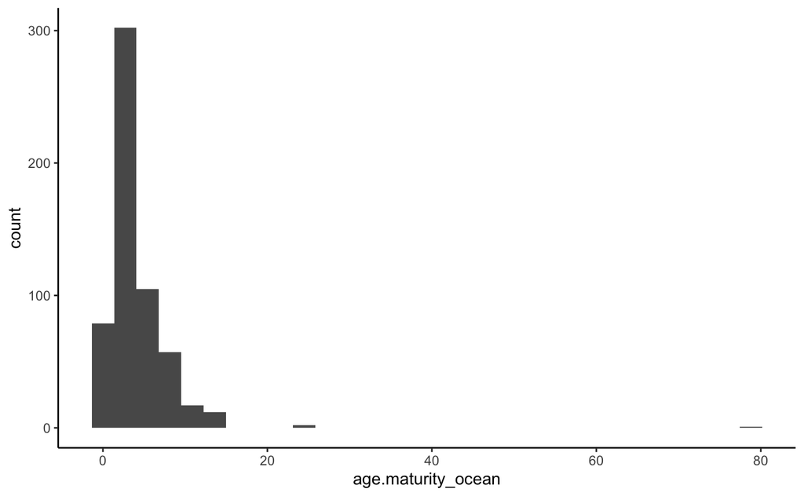

```r
spp_master_ztemp_seus_buoy.traits_scaled.unique <- unique(spp_master_ztemp_seus_buoy.traits_scaled[,.(spp, reg, age.maturity_ocean, age.max_ocean, tl_ocean, length.max_ocean)])

ggplot(spp_master_ztemp_seus_buoy.traits_scaled.unique, aes(x = age.maturity_ocean))  +
  geom_histogram() +
  theme_classic()
```

```r
summary(spp_master_ztemp_seus_buoy.traits_scaled.unique$age.maturity_ocean)
```

```
   Min. 1st Qu.  Median    Mean 3rd Qu.    Max.    NA's
  0.500   2.000   3.300   4.132   5.300  79.300      26
```

```
Warning: Removed 22 rows containing non-finite values (stat_bin).
```

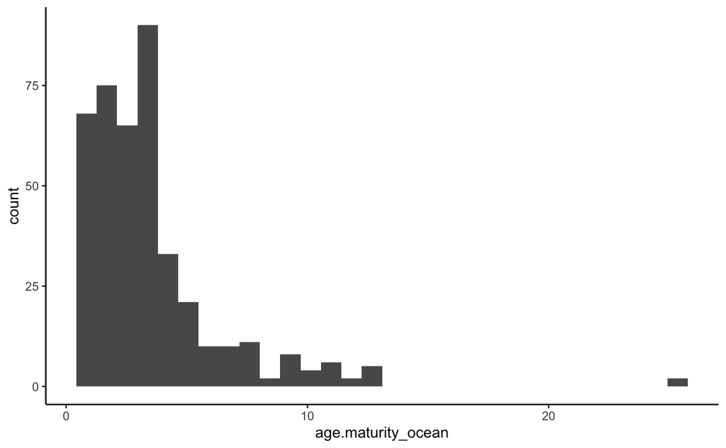

```r
#what about when we leave out ai, goa, and wctri

ggplot(spp_master_ztemp_seus_buoy.traits_scaled.unique[!(reg %in% c("ai","goa","wctri"))][!(reg %in% c("ai","goa","wctri"))], aes(x = age.maturity_ocean))  +
  geom_histogram() +
  theme_classic()
```

```r
summary(spp_master_ztemp_seus_buoy.traits_scaled.unique[!(reg %in% c("ai","goa","wctri"))][!(reg %in% c("ai","goa","wctri"))]$age.maturity_ocean)
```

```
   Min. 1st Qu.  Median    Mean 3rd Qu.    Max.    NA's
  0.500   1.875   2.800   3.512   4.000  25.000      22
```

Link up with spp key to add phylum, order, family, etc.

```r
spp_key <- fread(here::here("Data","Spp_master","spp_key.csv"))

spp_master_ztemp_seus_buoy.traits_scaled <- spp_key[spp_master_ztemp_seus_buoy.traits_scaled, on = "spp", nomatch = NULL]


#delete first year each region is sampled (because gains and losses are based on transitions between years, so we need 2 years of observations)

spp_master_ztemp_seus_buoy.traits_scaled[,min_year := min(year),.(reg)]

spp_master_ztemp_seus_buoy.traits_scaled <- spp_master_ztemp_seus_buoy.traits_scaled[year != min_year]
```

Prep for model runs

```r
#temp scaled vars only
#names of scaled columns
tempvars <- grep(".*temp.*scaled", names(spp_master_ztemp_seus_buoy.traits_scaled[!(reg %in% c("ai","goa","wctri"))]), value = T)

#other reference and trait columns we need
othervars_arrivals <- c("reg", "year", "col", "phylum","class","order","family","genus","spp", "age.max_ocean_scaled", "age.maturity_ocean_scaled", "tl_ocean_scaled", "length.max_ocean_scaled")

colstosaveforarrivals <- c(othervars_arrivals, tempvars)

#Arrival table
arrival.reduced_annual_obs <- spp_master_ztemp_seus_buoy.traits_scaled[,colstosaveforarrivals, with = F][!(reg %in% c("ai","goa","wctri"))] #reduces to columns we need

#Departure table

othervars_departure <- c("reg", "year", "now_ext", "phylum","class","order","family","genus","spp", "age.max_ocean_scaled", "age.maturity_ocean_scaled", "tl_ocean_scaled", "length.max_ocean_scaled")
colstosavefordeparture <- c(othervars_departure, tempvars)

departure.reduced_annual_obs <- spp_master_ztemp_seus_buoy.traits_scaled[,colstosavefordeparture, with = F][!(reg %in% c("ai","goa","wctri"))] #reduces to columns we need

spp_master_ztemp_seus_buoy.traits_scaled.6regions <- spp_master_ztemp_seus_buoy.traits_scaled[!(reg %in% c("ai","goa","wctri"))]

#save for specific figure code
saveRDS(spp_master_ztemp_seus_buoy.traits_scaled.6regions, here::here("figures","Supplemental","annual_sensitivity","spp_master_ztemp_seus_buoy.traits_scaled.6regions.rds"))
```

Making all models for arrival

```r
#to assist with convergence: year as factor
arrival.reduced_annual_obs[,year := as.factor(year)]

#delete any observations without full trait data
arrival.reduced_annual_obs.r <- arrival.reduced_annual_obs[complete.cases(arrival.reduced_annual_obs[ , .(age.max_ocean_scaled, age.maturity_ocean_scaled, length.max_ocean_scaled, tl_ocean_scaled)]),]

#save for specific figure code
saveRDS(arrival.reduced_annual_obs.r,file = here::here("figures","Supplemental","annual_sensitivity","arrival.reduced_annual_obs.r.rds"))


#for now, going with two traits and one temp variable
#going to make loop to make all models I need to look at with single variables
all.temp.variables <- colnames(arrival.reduced_annual_obs.r[,14:261])
all.temp.variables.0 <- c(0, all.temp.variables) #add 0 as option so models can just include traits
all.temp.variables.0 <- all.temp.variables.0[!grepl("*mean*", all.temp.variables.0)]#get rid of MEAN temp variables
all.trait.variables <- c(0, "tl_ocean_scaled", "age.max_ocean_scaled","age.maturity_ocean_scaled", "length.max_ocean_scaled",
                         "tl_ocean_scaled + age.max_ocean_scaled", "age.max_ocean_scaled + tl_ocean_scaled",
                         "tl_ocean_scaled + age.maturity_ocean_scaled", "age.maturity_ocean_scaled + tl_ocean_scaled",
                         "tl_ocean_scaled + length.max_ocean_scaled", "length.max_ocean_scaled + tl_ocean_scaled",
                         "age.max_ocean_scaled + age.maturity_ocean_scaled", "age.maturity_ocean_scaled + age.max_ocean_scaled",
                         "age.max_ocean_scaled + length.max_ocean_scaled", "length.max_ocean_scaled + age.max_ocean_scaled",
                         "age.maturity_ocean_scaled + length.max_ocean_scaled", "length.max_ocean_scaled + age.maturity_ocean_scaled")

sign <- c("+", "*")

full_var_set <- as.data.table(expand.grid(all.temp.variables.0, sign, all.trait.variables))

#delete repeats (just temperature and both + and *)

full_var_set.r <- full_var_set[!which((Var1 == "0" & Var2 =="*")|(Var3 == "0" & Var2 == "*")),] #this excludes repeats with *

#repeated rows with traits
repeats <- c("age.maturity_ocean_scaled + age.max_ocean_scaled","tl_ocean_scaled + age.maturity_ocean_scaled", "length.max_ocean_scaled + age.maturity_ocean_scaled", "age.maturity_ocean_scaled + length.max_ocean_scaled", "tl_ocean_scaled + length.max_ocean_scaled", "tl_ocean_scaled + age.max_ocean_scaled")

#delete rows with + and same combination of 2nd and 3rd traits
full_var_set.r2 <- full_var_set.r[!which(Var2 == "+"& Var3 %in% repeats)]


#build datatable
arrival_model_comparison_traits_annual_only <- as.data.table(matrix(nrow = nrow(full_var_set.r2)))
arrival_model_comparison_traits_annual_only[, temp_variable:=as.factor(V1)][, sign:=as.factor(V1)][, trait_variable:=as.factor(V1)][, AICc:=as.numeric(V1)][, converge:= as.logical(V1)]
arrival_model_comparison_traits_annual_only[, V1 := NULL]

for (i in 1:nrow(full_var_set.r2)){

  temp <- full_var_set.r2$Var1[i]
  sign <- full_var_set.r2$Var2[i]
  trait <- full_var_set.r2$Var3[i]

  raw_form <- ifelse(temp == 0 & trait != 0,
      paste("col ~", trait, "+ (1|reg)  + (1|class) + (1|order) + (1|family) + (1|genus) + (1|spp)"),
          ifelse(temp != 0 & trait == 0,
           paste("col ~", temp, "+ (1|reg)  + (1|class) + (1|order) + (1|family) + (1|genus) + (1|spp)"),
              ifelse(temp == 0 & trait == 0,
              paste("col ~", "+ (1|reg)  + (1|class) + (1|order) + (1|family) + (1|genus) + (1|spp)"),
                paste("col ~",temp,sign,trait, "+ (1|reg)  + (1|class) + (1|order) + (1|family) + (1|genus) + (1|spp)"))))

  formula <- as.formula(raw_form)

  mod <- glmer(formula, family = binomial, data = arrival.reduced_annual_obs.r, nAGQ = 0)

  arrival_model_comparison_traits_annual_only[i,temp_variable := full_var_set.r2$Var1[i]]
  arrival_model_comparison_traits_annual_only[i,sign := full_var_set.r2$Var2[i]]
  arrival_model_comparison_traits_annual_only[i,trait_variable := full_var_set.r2$Var3[i]]
  arrival_model_comparison_traits_annual_only[i,AICc := AICc(mod)]

  warning <- mod@optinfo$conv$lme4$messages[2]
  converges <- ifelse(is.null(warning) == TRUE, T, F)

  arrival_model_comparison_traits_annual_only[i, converge := converges]

  print(paste(i, nrow(arrival_model_comparison_traits_annual_only), sep = "/"))

}


saveRDS(arrival_model_comparison_traits_annual_only, here::here("Model_results","Traits","arrival_model_comparison_traits_annual_obs.rds"))

fwrite(arrival_model_comparison_traits_annual_only, here::here("Model_results","Traits","arrival_model_comparison_traits_annual_obs.csv"))

arrival_model_comparison_traits_annual_only <- readRDS(here::here("Model_results","Traits","arrival_model_comparison_traits_annual_obs.rds"))
```

Making all models for departure

```r
departure_model_comparison_traits_annual_obs <- as.data.table(matrix(nrow = nrow(full_var_set.r2)))
```

[output not shown]

Next step is to look at RVI (relative variable importance)

RVI for Temperature Trait Arrival Models

```r
#only raw temp has lag of 10 years, which means variable importance comparisons are unbalanced so I will get rid of these rows
arrival_model_comparisons_traits.lag9max_annual_obs <- arrival_model_comparison_traits_annual_only[!grepl("lag10", temp_variable), ]

#add ∆AIC to tables
min_arrival_AICc_trait <- min(arrival_model_comparisons_traits.lag9max_annual_obs[, AICc])
arrival_model_comparisons_traits.lag9max_annual_obs[,"deltaAICc" := (AICc - min_arrival_AICc_trait)]

#add relative likelihood exp( -0.5 * ∆AIC score for that model)
arrival_model_comparisons_traits.lag9max_annual_obs[,"rel_likelihood" := exp((-0.5 * deltaAICc))]
#sum relative likelihoods across all models
arrival_model_comparisons_traits.lag9max_annual_obs.likelihoodsum <- sum(arrival_model_comparisons_traits.lag9max_annual_obs[, rel_likelihood])
#Akaike weight for a model is this rel_likelihood devided by the sum of these values across all models
arrival_model_comparisons_traits.lag9max_annual_obs[,"akaike_weight" := rel_likelihood/arrival_model_comparisons_traits.lag9max_annual_obs.likelihoodsum]

#I want to look at relative importance FOR
#bottom/surface (bottom = includes sbt, grepl("sbt", variable))
arrival_bottom_importance <- sum(arrival_model_comparisons_traits.lag9max_annual_obs[grep("sbt", temp_variable), ]$akaike_weight)
arrival_surface_importance <- sum(arrival_model_comparisons_traits.lag9max_annual_obs[grep("sst", temp_variable), ]$akaike_weight)
  arrival_bottom_importance.n <- count(arrival_model_comparisons_traits.lag9max_annual_obs[grepl("sbt", temp_variable), ]) #3060
  arrival_surface_importance.n <- count(arrival_model_comparisons_traits.lag9max_annual_obs[grepl("sst", temp_variable), ]) #3060

#lag\not lagged (grepl("lag", variable))
arrival_lag_importance <- sum(arrival_model_comparisons_traits.lag9max_annual_obs[grep("lag", temp_variable), ]$akaike_weight)
arrival_nolag_importance <- sum(arrival_model_comparisons_traits.lag9max_annual_obs[!grep("lag", temp_variable), ]$akaike_weight)
  arrival_lag_importance.n <- count(arrival_model_comparisons_traits.lag9max_annual_obs[grepl("lag", temp_variable), ]) #5508 models include a lag
  arrival_nolag_importance.n <- count(arrival_model_comparisons_traits.lag9max_annual_obs[!grepl("lag", temp_variable), ]) #646 don't include a lag (no lag OR trait only)


  #34 models have NO temp variable


#absolute (grepl("abs", variable))
arrival_abs_importance <- sum(arrival_model_comparisons_traits.lag9max_annual_obs[grep("abs", temp_variable), ]$akaike_weight)
  arrival_abs_importance.n <- count(arrival_model_comparisons_traits.lag9max_annual_obs[grepl("abs", temp_variable), ])#2040

#raw (!grepl("change"))
arrival_raw_importance <- sum(arrival_model_comparisons_traits.lag9max_annual_obs[!grep("change", temp_variable), ][temp_variable != 0,]$akaike_weight)
  arrival_raw_importance.n <- count(arrival_model_comparisons_traits.lag9max_annual_obs[!grepl("change", temp_variable), ][temp_variable != 0]) #2040

#change (grepl("change", temp_variable), (!grepl("abs")))
arrival_change_importance <- sum(arrival_model_comparisons_traits.lag9max_annual_obs[grep("change", temp_variable), ][!grep("abs", temp_variable),]$akaike_weight)
  arrival_change_importance.n <- count(arrival_model_comparisons_traits.lag9max_annual_obs[grep("change", temp_variable), ][!grep("abs", temp_variable),])#2040


#type of temp temp_variable (max, min, seas)
arrival_max_temp_importance <- sum(arrival_model_comparisons_traits.lag9max_annual_obs[grep("max", temp_variable), ]$akaike_weight)
arrival_min_temp_importance <- sum(arrival_model_comparisons_traits.lag9max_annual_obs[grep("min", temp_variable), ]$akaike_weight)
arrival_seas_temp_importance <- sum(arrival_model_comparisons_traits.lag9max_annual_obs[grep("seas", temp_variable), ]$akaike_weight)
  arrival_max_temp_importance.n <- count(arrival_model_comparisons_traits.lag9max_annual_obs[grepl("max", temp_variable), ]) #2040
  arrival_min_temp_importance.n <- count(arrival_model_comparisons_traits.lag9max_annual_obs[grepl("min", temp_variable), ]) #2040
  arrival_seas_temp_importance.n <- count(arrival_model_comparisons_traits.lag9max_annual_obs[grepl("seas", temp_variable), ]) #2040


#traits included
arrival_age.max_importance <- sum(arrival_model_comparisons_traits.lag9max_annual_obs[grep("age.max", trait_variable), ]$akaike_weight)
arrival_age.maturity_importance <- sum(arrival_model_comparisons_traits.lag9max_annual_obs[grep("age.maturity", trait_variable), ]$akaike_weight)
arrival_tl_importance <- sum(arrival_model_comparisons_traits.lag9max_annual_obs[grep("tl", trait_variable), ]$akaike_weight)
arrival_length.max_importance <- sum(arrival_model_comparisons_traits.lag9max_annual_obs[grep("length", trait_variable),]$akaike_weight)
  arrival_age.max_importance.n <- count(arrival_model_comparisons_traits.lag9max_annual_obs[grepl("age.max", trait_variable), ]) #2534
  arrival_age.maturity_importance.n <- count(arrival_model_comparisons_traits.lag9max_annual_obs[grepl("age.maturity", trait_variable), ]) #2534
  arrival_tl_importance.n <- count(arrival_model_comparisons_traits.lag9max_annual_obs[grepl("tl", trait_variable), ]) #2534
  arrival_length.max_importance.n <- count(arrival_model_comparisons_traits.lag9max_annual_obs[grepl("length", trait_variable),]) #2534


#interaction between trait and temperature
arrival_interaction_temp_trait_importance <- sum(arrival_model_comparisons_traits.lag9max_annual_obs[grep("\\*", sign), ]$akaike_weight)
  arrival_interaction_temp_trait_importance.n <- count(arrival_model_comparisons_traits.lag9max_annual_obs[grepl("\\*", sign), ]) #3077


#save this table
saveRDS(arrival_model_comparisons_traits.lag9max_annual_obs,file = here::here( "Model_results/Traits/arrival_model_comparison_traits_annual_obs.rds"))
```

```r
arrival_departure <- c("arrival","arrival","arrival","arrival","arrival", "arrival","arrival", "arrival", "arrival","arrival", "arrival","arrival", "arrival", "arrival","arrival")
type <- c("depth", "depth", "lag", "lag", "Change?", "Change?", "Change?", "Temp", "Temp", "Temp", "Trait", "Trait", "Trait","Trait", "Interaction")
variable <- c("bottom", "surface", "no_lag", "lagged", "absolute_value_change", "change", "raw", "Min", "Max", "Seas", "age.max", "age.maturity", "tl", "length.max", "tempxtrait")
value <- c(arrival_bottom_importance, arrival_surface_importance, arrival_nolag_importance, arrival_lag_importance, arrival_abs_importance, arrival_change_importance, arrival_raw_importance, arrival_min_temp_importance, arrival_max_temp_importance, arrival_seas_temp_importance, arrival_age.max_importance, arrival_age.maturity_importance, arrival_tl_importance, arrival_length.max_importance, arrival_interaction_temp_trait_importance)

RVI_arrival_traits <- data.table(arrival_departure, type, variable, value)
```

Departure

```r
#only raw temp has lag of 10 years, which means variable importance comparisons are unbalanced so I will get rid of these rows
departure_model_comparisons_traits.lag9max <- departure_model_comparison_traits_annual_only[!grepl("lag10", temp_variable), ]


#add ∆AIC to tables
min_departure_AICc_trait <- min(departure_model_comparisons_traits.lag9max[, AICc])
departure_model_comparisons_traits.lag9max[,"deltaAICc" := (AICc - min_departure_AICc_trait)]

#add relative likelihood exp( -0.5 * ∆AIC score for that model)
departure_model_comparisons_traits.lag9max[,"rel_likelihood" := exp((-0.5 * deltaAICc))]
#sum relative likelihoods across all models
departure_model_comparisons_traits.lag9max.likelihoodsum <- sum(departure_model_comparisons_traits.lag9max[, rel_likelihood])
#Akaike weight for a model is this rel_likelihood devided by the sum of these values across all models
departure_model_comparisons_traits.lag9max[,"akaike_weight" := rel_likelihood/departure_model_comparisons_traits.lag9max.likelihoodsum]

#I want to look at relative importance FOR
#bottom/surface (bottom = includes sbt, grepl("sbt", variable))
departure_bottom_importance <- sum(departure_model_comparisons_traits.lag9max[grep("sbt", temp_variable), ]$akaike_weight)
  departure_bottom_importance.n <- count(departure_model_comparisons_traits.lag9max[grepl("sbt", temp_variable), ]) #3060
departure_surface_importance <- sum(departure_model_comparisons_traits.lag9max[grep("sst", temp_variable), ]$akaike_weight)
  departure_surface_importance.n <- count(departure_model_comparisons_traits.lag9max[grepl("sst", temp_variable), ]) #3060

#lag\not lagged (grepl("lag", variable))
departure_lag_importance <- sum(departure_model_comparisons_traits.lag9max[grep("lag", temp_variable), ]$akaike_weight)
  departure_lag_importance.n <- count(departure_model_comparisons_traits.lag9max[grepl("lag", temp_variable),]) #5508
departure_nolag_importance <- sum(departure_model_comparisons_traits.lag9max[!grep("lag", temp_variable), ]$akaike_weight)
  departure_nolag_importance.n <- count(departure_model_comparisons_traits.lag9max[!grepl("lag", temp_variable), ]) #646

  #absolute (grepl("abs", variable))
departure_abs_importance <- sum(departure_model_comparisons_traits.lag9max[grep("abs", temp_variable), ]$akaike_weight)
  departure_abs_importance.n <- count(departure_model_comparisons_traits.lag9max[grepl("abs", temp_variable), ]) #2040

  #raw (!grepl("change"))
departure_raw_importance <- sum(departure_model_comparisons_traits.lag9max[!grep("change", temp_variable), ][temp_variable != 0,]$akaike_weight)
  departure_raw_importance.n <- count(departure_model_comparisons_traits.lag9max[!grepl("change", temp_variable), ][temp_variable != 0,]) #2040

#change (grepl("change", temp_variable), (!grepl("abs")))
departure_change_importance <- sum(departure_model_comparisons_traits.lag9max[grep("change", temp_variable), ][!grep("abs", temp_variable),]$akaike_weight)
  departure_change_importance.n <- count(departure_model_comparisons_traits.lag9max[grepl("change", temp_variable), ][!grepl("abs", temp_variable),])#2040

#type of temp temp_variable (max, min, seas)
departure_max_temp_importance <- sum(departure_model_comparisons_traits.lag9max[grep("max", temp_variable), ]$akaike_weight)
  departure_max_temp_importance.n <- count(departure_model_comparisons_traits.lag9max[grepl("max", temp_variable), ]) #2040
departure_min_temp_importance <- sum(departure_model_comparisons_traits.lag9max[grep("min", temp_variable), ]$akaike_weight)
  departure_min_temp_importance.n <- count(departure_model_comparisons_traits.lag9max[grepl("min", temp_variable), ]) #2040
departure_seas_temp_importance <- sum(departure_model_comparisons_traits.lag9max[grep("seas", temp_variable), ]$akaike_weight)
  departure_seas_temp_importance.n <- count(departure_model_comparisons_traits.lag9max[grepl("seas", temp_variable), ]) #2040

#traits included
departure_age.max_importance <- sum(departure_model_comparisons_traits.lag9max[grep("age.max", trait_variable), ]$akaike_weight)
departure_age.maturity_importance <- sum(departure_model_comparisons_traits.lag9max[grep("age.maturity", trait_variable), ]$akaike_weight)
departure_tl_importance <- sum(departure_model_comparisons_traits.lag9max[grep("tl", trait_variable), ]$akaike_weight)
departure_length.max_importance <- sum(departure_model_comparisons_traits.lag9max[grep("length", trait_variable),]$akaike_weight)

  departure_age.max_importance.n <- count(departure_model_comparisons_traits.lag9max[grepl("age.max", trait_variable), ]) #2534
  departure_age.maturity_importance.n <- count(departure_model_comparisons_traits.lag9max[grepl("age.maturity", trait_variable), ]) #2534
  departure_tl_importance.n <- count(departure_model_comparisons_traits.lag9max[grepl("tl", trait_variable), ]) #2534
  departure_length.max_importance.n <- count(departure_model_comparisons_traits.lag9max[grepl("length", trait_variable),]) #2534

#interaction between trait and temperature
departure_interaction_temp_trait_importance <- sum(departure_model_comparisons_traits.lag9max[grep("\\*", sign), ]$akaike_weight)
  departure_interaction_temp_trait_importance.n <- count(departure_model_comparisons_traits.lag9max[grepl("\\*", sign), ]) #3077


#save this table
saveRDS(departure_model_comparisons_traits.lag9max, here::here( "Model_results/Traits/departure_model_comparison_traits_annual_obs.rds"))
```

```r
arrival_departure <- c("departure","departure","departure","departure","departure", "departure","departure", "departure", "departure","departure", "departure","departure", "departure", "departure","departure")
type <- c("depth", "depth", "lag", "lag", "Change?", "Change?", "Change?", "Temp", "Temp", "Temp", "Trait", "Trait", "Trait","Trait", "Interaction")
variable <- c("bottom", "surface", "no_lag", "lagged", "absolute_value_change", "change", "raw", "Min", "Max", "Seas", "age.max", "age.maturity", "tl", "length.max", "tempxtrait")
value <- c(departure_bottom_importance, departure_surface_importance, departure_nolag_importance, departure_lag_importance, departure_abs_importance, departure_change_importance, departure_raw_importance, departure_min_temp_importance, departure_max_temp_importance, departure_seas_temp_importance, departure_age.max_importance, departure_age.maturity_importance, departure_tl_importance, departure_length.max_importance, departure_interaction_temp_trait_importance)

RVI_departure_traits <- data.table(arrival_departure, type, variable, value)
```

Merge RVI tables for colonization and extinction with traits, and then graph

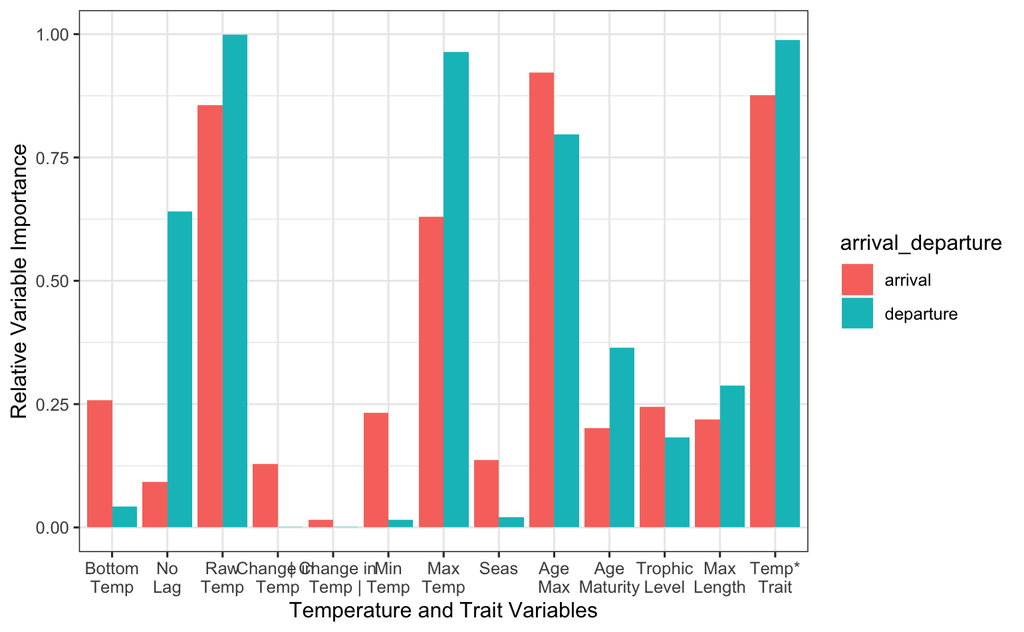

```r
RVI_trait_table <- as.data.table(rbind(RVI_arrival_traits, RVI_departure_traits)) #bind RVI for colonizations and extinctions

RVI_trait_table.r <- RVI_trait_table[!grep("surface", variable)][!grep("lagged", variable)]

#change order of factor levels
RVI_trait_table.r[, variable := factor(variable, levels = c("bottom", "no_lag", "raw", "change", "absolute_value_change", "Min", "Max", "Seas", "age.max", "age.maturity", "tl", "length.max", "tempxtrait"))]

save(RVI_trait_table, file = "RVI_trait_table_annual_obs.Rdata")

ggplot(data = RVI_trait_table.r, aes(x=variable, y = value, fill = arrival_departure)) +
  geom_bar(stat = "identity", position = "dodge") +
  scale_x_discrete(breaks = c("bottom", "no_lag", "raw", "change", "absolute_value_change", "Min", "Max", "Seas", "age.max", "age.maturity", "tl", "length.max", "tempxtrait"), labels = c("Bottom\nTemp", "No\nLag", "Raw\nTemp", "Change in \nTemp", "| Change in\n Temp |", "Min\nTemp", "Max\nTemp", "Seas", "Age\nMax", "Age\nMaturity", "Trophic\nLevel", "Max\nLength" , "Temp*\nTrait")) +
  labs(x = "Temperature and Trait Variables", y = "Relative Variable Importance")  +
  theme_bw()
```

Another way to visualize

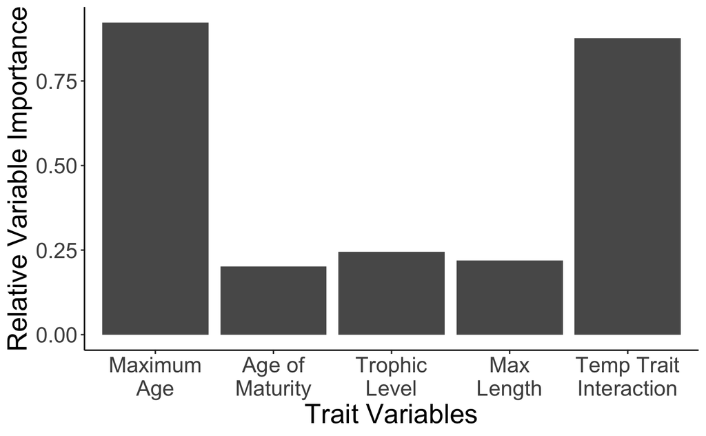

```r
#put levels into correct order for viewing
RVI_trait_table[
  , variable := factor(variable, levels = c("bottom", "surface", "absolute_value_change", "change", "raw", "no_lag", "lagged", "Min", "Max", "Seas", "age.max", "age.maturity", "tl","length.max", "tempxtrait"))][
    ,type := factor(type, levels = c("Change?", "depth", "lag", "Temp", "Trait", "Interaction"))]
#make types factors as well

#colonization
RVI_arrival_trait_plot <- ggplot(data = RVI_trait_table[arrival_departure == "arrival" & (type == "Trait" | type == "Interaction")], aes(x=variable, y = value)) +
  geom_bar(stat= "identity") +
  scale_x_discrete(breaks = c("age.max", "age.maturity", "tl", "length.max", "tempxtrait"), labels = c("Maximum\nAge", "Age of\nMaturity", "Trophic\nLevel","Max\nLength", "Temp Trait\nInteraction")) +
  labs(x = "Trait Variables", y = "Relative Variable Importance") +
  theme_classic() +
  theme(text = element_text(size = 20))
#departure
RVI_departure_trait_plot <- ggplot(data = RVI_trait_table[arrival_departure == "departure" & (type == "Trait" | type == "Interaction")], aes(x=variable, y = value)) +
  geom_bar(stat= "identity") +
  scale_x_discrete(breaks = c("age.max", "age.maturity", "tl","length.max",  "tempxtrait"), labels = c("Maximum\nAge", "Age of\nMaturity", "Trophic\nLevel","Max\nLength", "Temp Trait\nInteraction")) +
  labs(x = "Trait Variables", y = "Relative Variable Importance") +
  theme_classic() +
  theme(text = element_text(size = 20))

RVI_arrival_trait_plot
```

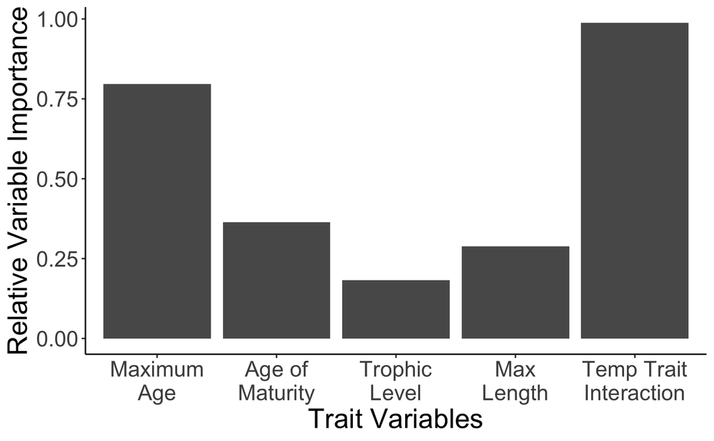

```r
RVI_departure_trait_plot
```

```r
save(RVI_trait_table, file = "RVI_trait_table_annual_obs.Rdata")
```

Let’s see how the RVI importance varies by looking at specific lag values for these trait models

```r
#first, table for lags
lags_v_RVI_trait <- data.table(arrival_lag = c(0:9), arrival_RVI = 0, departure_RVI = 0)
#arrival
lags_v_RVI_trait[1,2] <- 1-sum(arrival_model_comparisons_traits.lag9max_annual_obs[grep("lag", temp_variable), ]$akaike_weight)
lags_v_RVI_trait[2,2] <- sum(arrival_model_comparisons_traits.lag9max_annual_obs[grep("lag1", temp_variable), ]$akaike_weight)
lags_v_RVI_trait[3,2] <- sum(arrival_model_comparisons_traits.lag9max_annual_obs[grep("lag2", temp_variable), ]$akaike_weight)
lags_v_RVI_trait[4,2] <- sum(arrival_model_comparisons_traits.lag9max_annual_obs[grep("lag3", temp_variable), ]$akaike_weight)
lags_v_RVI_trait[5,2] <- sum(arrival_model_comparisons_traits.lag9max_annual_obs[grep("lag4", temp_variable), ]$akaike_weight)
lags_v_RVI_trait[6,2] <- sum(arrival_model_comparisons_traits.lag9max_annual_obs[grep("lag5", temp_variable), ]$akaike_weight)
lags_v_RVI_trait[7,2] <- sum(arrival_model_comparisons_traits.lag9max_annual_obs[grep("lag6", temp_variable), ]$akaike_weight)
lags_v_RVI_trait[8,2] <- sum(arrival_model_comparisons_traits.lag9max_annual_obs[grep("lag7", temp_variable), ]$akaike_weight)
lags_v_RVI_trait[9,2] <- sum(arrival_model_comparisons_traits.lag9max_annual_obs[grep("lag8", temp_variable), ]$akaike_weight)
lags_v_RVI_trait[10,2] <- sum(arrival_model_comparisons_traits.lag9max_annual_obs[grep("lag9", temp_variable), ]$akaike_weight)
#departure
lags_v_RVI_trait[1,3] <- 1-sum(departure_model_comparisons_traits.lag9max[grep("lag", temp_variable), ]$akaike_weight)
lags_v_RVI_trait[2,3] <- sum(departure_model_comparisons_traits.lag9max[grep("lag1", temp_variable), ]$akaike_weight)
lags_v_RVI_trait[3,3] <- sum(departure_model_comparisons_traits.lag9max[grep("lag2", temp_variable), ]$akaike_weight)
lags_v_RVI_trait[4,3] <- sum(departure_model_comparisons_traits.lag9max[grep("lag3", temp_variable), ]$akaike_weight)
lags_v_RVI_trait[5,3] <- sum(departure_model_comparisons_traits.lag9max[grep("lag4", temp_variable), ]$akaike_weight)
lags_v_RVI_trait[6,3] <- sum(departure_model_comparisons_traits.lag9max[grep("lag5", temp_variable), ]$akaike_weight)
lags_v_RVI_trait[7,3] <- sum(departure_model_comparisons_traits.lag9max[grep("lag6", temp_variable), ]$akaike_weight)
lags_v_RVI_trait[8,3] <- sum(departure_model_comparisons_traits.lag9max[grep("lag7", temp_variable), ]$akaike_weight)
lags_v_RVI_trait[9,3] <- sum(departure_model_comparisons_traits.lag9max[grep("lag8", temp_variable), ]$akaike_weight)
lags_v_RVI_trait[10,3] <- sum(departure_model_comparisons_traits.lag9max[grep("lag9", temp_variable), ]$akaike_weight)

RVI_lags_traits <- ggplot(data = lags_v_RVI_trait, aes(x = arrival_lag)) +
  geom_line(aes(y = arrival_RVI)) +
  geom_line(aes(y = departure_RVI), linetype = "dashed") +
  labs(x = "Lag (years)", y = "Relative Variable Importance") +
  theme_classic() +
  theme(text = element_text(size = 22, color = "black")) +
  scale_x_continuous(breaks = 0:10) +
  scale_y_continuous(limits = 0:1)

save(RVI_arrival_trait_plot, RVI_departure_trait_plot, RVI_lags_traits, file = "RVI_plots_traits_annual_obs.Rdata")

setEPS()
postscript("RVI_arrival_trait_plot_annual_obs.eps")
RVI_arrival_trait_plot
dev.off()
```

```r
setEPS()
postscript("RVI_departure_trait_plot_annual_obs.eps")
```

```r
RVI_departure_trait_plot
dev.off()
```

```r
setEPS()
postscript("RVI_lags_trait_plot_annual_obs.eps")
```

```r
RVI_lags_traits
dev.off()
```

Comparisons of coefficients of top models

Top arrival models

```r
arrival.reduced_annual_obs.r <- readRDS(file = here::here("figures","Supplemental","annual_sensitivity","arrival.reduced_annual_obs.r.rds"))


mod1_arrival <- glmer(col ~ max_sst_temp_change_abs_lag1_scaled * age.max_ocean_scaled + (1|reg)  + (1|class) + (1|order) + (1|family) + (1|genus) + (1|spp), family = "binomial", data = arrival.reduced_annual_obs.r, nAGQ = 0)

mod2_arrival <- glmer(col ~ max_sst_temp_change_abs_lag1_scaled * age.max_ocean_scaled + tl_ocean_scaled + (1|reg)  + (1|class) + (1|order) + (1|family) + (1|genus) + (1|spp), family = "binomial", data = arrival.reduced_annual_obs.r, nAGQ = 0)

mod3_arrival <- glmer(col ~ max_sst_temp_change_abs_lag1_scaled * age.max_ocean_scaled + age.maturity_ocean_scaled + (1|reg)  + (1|class) + (1|order) + (1|family) + (1|genus) + (1|spp), family = "binomial", data = arrival.reduced_annual_obs.r, nAGQ = 0)

mod4_arrival <- glmer(col ~ max_sst_temp_change_abs_lag1_scaled * age.max_ocean_scaled + length.max_ocean_scaled + (1|reg)  + (1|class) + (1|order) + (1|family) + (1|genus) + (1|spp), family = "binomial", data = arrival.reduced_annual_obs.r, nAGQ = 0)

mod_traitonly_arrival <- glmer(col ~ age.max_ocean_scaled + (1|reg)  + (1|class) + (1|order) + (1|family) + (1|genus) + (1|spp), family = "binomial", data = arrival.reduced_annual_obs.r, nAGQ = 0)

mod_temponly_arrival <- glmer(col ~ max_sst_temp_change_abs_lag1_scaled + (1|reg)  + (1|class) + (1|order) + (1|family) + (1|genus) + (1|spp), family = "binomial", data = arrival.reduced_annual_obs.r, nAGQ = 0)

mod_null_arrival <- glmer(col ~ (1|reg)  + (1|class) + (1|order) + (1|family) + (1|genus) + (1|spp), family = "binomial", data = arrival.reduced_annual_obs.r, nAGQ = 0)


summary(mod1_arrival)[[10]]
```

```
                                                           Estimate Std. Error    z value
(Intercept)                                              -3.5227392 0.35126218 -10.028803
max_sst_temp_change_abs_lag1_scaled                      -0.2139673 0.08151691  -2.624821
age.max_ocean_scaled                                     -0.6088983 0.21970061  -2.771491
max_sst_temp_change_abs_lag1_scaled:age.max_ocean_scaled -0.3649846 0.14527145  -2.512432
                                                             Pr(>|z|)
(Intercept)                                              1.138891e-23
max_sst_temp_change_abs_lag1_scaled                      8.669444e-03
age.max_ocean_scaled                                     5.580015e-03
max_sst_temp_change_abs_lag1_scaled:age.max_ocean_scaled 1.199023e-02
```

```r
r.squaredGLMM(mod1_arrival)
```

```
                   R2m       R2c
theoretical 0.03066669 0.4523032
delta       0.01072512 0.1581849
```

```r
summary(mod2_arrival)[[10]]
```

```
                                                           Estimate Std. Error     z value
(Intercept)                                              -3.5272302 0.34976481 -10.0845772
max_sst_temp_change_abs_lag1_scaled                      -0.2137092 0.08146763  -2.6232407
age.max_ocean_scaled                                     -0.5711410 0.22230051  -2.5692293
tl_ocean_scaled                                          -0.1070142 0.11700059  -0.9146468
max_sst_temp_change_abs_lag1_scaled:age.max_ocean_scaled -0.3631930 0.14495583  -2.5055426
                                                             Pr(>|z|)
(Intercept)                                              6.464284e-24
max_sst_temp_change_abs_lag1_scaled                      8.709772e-03
age.max_ocean_scaled                                     1.019250e-02
tl_ocean_scaled                                          3.603771e-01
max_sst_temp_change_abs_lag1_scaled:age.max_ocean_scaled 1.222637e-02
```

```r
r.squaredGLMM(mod2_arrival)
```

```
                   R2m       R2c
theoretical 0.03247750 0.4514739
delta       0.01134724 0.1577395
```

```r
summary(mod3_arrival)[[10]]
```

```
                                                           Estimate Std. Error   z value
(Intercept)                                              -3.5202740 0.35242918 -9.988600
max_sst_temp_change_abs_lag1_scaled                      -0.2135065 0.08149228 -2.619960
age.max_ocean_scaled                                     -0.5218851 0.27319907 -1.910274
age.maturity_ocean_scaled                                -0.1360657 0.24623271 -0.552590
max_sst_temp_change_abs_lag1_scaled:age.max_ocean_scaled -0.3637690 0.14512138 -2.506653
                                                             Pr(>|z|)
(Intercept)                                              1.709797e-23
max_sst_temp_change_abs_lag1_scaled                      8.794020e-03
age.max_ocean_scaled                                     5.609795e-02
age.maturity_ocean_scaled                                5.805442e-01
max_sst_temp_change_abs_lag1_scaled:age.max_ocean_scaled 1.218801e-02
```

```r
r.squaredGLMM(mod3_arrival)
```

```
                   R2m       R2c
theoretical 0.03215117 0.4531821
delta       0.01125604 0.1586578
```

```r
summary(mod4_arrival)[[10]]
```

```
                                                            Estimate Std. Error
(Intercept)                                              -3.53668557 0.35257595
max_sst_temp_change_abs_lag1_scaled                      -0.21423118 0.08155623
age.max_ocean_scaled                                     -0.65002292 0.25908893
length.max_ocean_scaled                                   0.04847922 0.14934643
max_sst_temp_change_abs_lag1_scaled:age.max_ocean_scaled -0.36571366 0.14544965
                                                             z value     Pr(>|z|)
(Intercept)                                              -10.0309892 1.113949e-23
max_sst_temp_change_abs_lag1_scaled                       -2.6267913 8.619419e-03
age.max_ocean_scaled                                      -2.5088796 1.211148e-02
length.max_ocean_scaled                                    0.3246091 7.454769e-01
max_sst_temp_change_abs_lag1_scaled:age.max_ocean_scaled  -2.5143660 1.192466e-02
```

```r
r.squaredGLMM(mod4_arrival)
```

```
                   R2m       R2c
theoretical 0.03120674 0.4516151
delta       0.01090508 0.1578153
```

```r
summary(mod_traitonly_arrival)[[10]]
```

```
                       Estimate Std. Error   z value     Pr(>|z|)
(Intercept)          -3.4818141  0.3499347 -9.949898 2.524428e-23
age.max_ocean_scaled -0.5140491  0.2138271 -2.404041 1.621496e-02
```

```r
r.squaredGLMM(mod_traitonly_arrival)
```

```
                    R2m       R2c
theoretical 0.016712301 0.4443803
delta       0.005790357 0.1539657
```

```r
summary(mod_temponly_arrival)[[10]]
```

```
                                      Estimate Std. Error   z value     Pr(>|z|)
(Intercept)                         -3.4399612 0.34547197 -9.957280 2.343869e-23
max_sst_temp_change_abs_lag1_scaled -0.1133014 0.06910268 -1.639609 1.010864e-01
```

```r
r.squaredGLMM(mod_temponly_arrival)
```

```
                    R2m       R2c
theoretical 0.001375504 0.4413034
delta       0.000474856 0.1523482
```

```r
summary(mod_null_arrival)[[10]]
```

```
             Estimate Std. Error   z value     Pr(>|z|)
(Intercept) -3.433626  0.3445007 -9.966964 2.126293e-23
```

```r
r.squaredGLMM(mod_null_arrival)
```

```
            R2m       R2c
theoretical   0 0.4401878
delta         0 0.1517647
```

```r
AICc(mod1_arrival)-AICc(mod1_arrival)
```

```
[1] 0
```

```r
AICc(mod2_arrival)-AICc(mod1_arrival)
```

```
[1] 0.9485168
```

```r
AICc(mod3_arrival)-AICc(mod1_arrival)
```

```
[1] 1.755429
```

```r
AICc(mod4_arrival)-AICc(mod1_arrival)
```

```
[1] 1.859979
```

```r
AICc(mod_traitonly_arrival)-AICc(mod1_arrival) #18.46734
```

```
[1] 5.718822
```

```r
AICc(mod_temponly_arrival)-AICc(mod1_arrival) #8.211203
```

```
[1] 9.135073
```

```r
AICc(mod_null_arrival)-AICc(mod1_arrival) #24.025178
```

```
[1] 9.934246
```

Top departure models

```r
departure.reduced_annual_obs.r <- readRDS(file = here::here("figures","Supplemental","annual_sensitivity","departure.reduced_annual_obs.r.rds"))

mod1_departure <- glmer(now_ext ~
max_sst_temp_lag1_scaled * age.max_ocean_scaled+ (1|reg)  + (1|class) + (1|order) + (1|family) + (1|genus) + (1|spp), family = "binomial", data = departure.reduced_annual_obs.r, nAGQ = 0)

mod2_departure <- glmer(now_ext ~ max_sst_temp_scaled * age.max_ocean_scaled+ (1|reg)  + (1|class) + (1|order) + (1|family) + (1|genus) + (1|spp), family = "binomial", data = departure.reduced_annual_obs.r, nAGQ = 0)

mod3_departure <- glmer(now_ext ~ max_sst_temp_lag1_scaled * age.max_ocean_scaled + age.maturity_ocean_scaled+ (1|reg)  + (1|class) + (1|order) + (1|family) + (1|genus) + (1|spp), family = "binomial", data = departure.reduced_annual_obs.r, nAGQ = 0)

mod4_departure <- glmer(now_ext ~ max_sst_temp_lag1_scaled * age.max_ocean_scaled + tl_ocean_scaled+ (1|reg)  + (1|class) + (1|order) + (1|family) + (1|genus) + (1|spp), family = "binomial", data = departure.reduced_annual_obs.r, nAGQ = 0)

mod5_departure <- glmer(now_ext ~ max_sst_temp_lag1_scaled * age.max_ocean_scaled + length.max_ocean_scaled + (1|reg)  + (1|class) + (1|order) + (1|family) + (1|genus) + (1|spp), family = "binomial", data = departure.reduced_annual_obs.r, nAGQ = 0)

mod6_departure <- glmer(now_ext ~ max_sst_temp_scaled * age.max_ocean_scaled + age.maturity_ocean_scaled+ (1|reg)  + (1|class) + (1|order) + (1|family) + (1|genus) + (1|spp), family = "binomial", data = departure.reduced_annual_obs.r, nAGQ = 0)

mod_traitonly_departure <- glmer(now_ext ~ age.max_ocean_scaled + (1|reg)  + (1|class) + (1|order) + (1|family) + (1|genus) + (1|spp), family = "binomial", data = departure.reduced_annual_obs.r, nAGQ = 0)

mod_temponly_departure <- glmer(now_ext ~ max_sst_temp_scaled + (1|reg)  + (1|class) + (1|order) + (1|family) + (1|genus) + (1|spp), family = "binomial", data = departure.reduced_annual_obs.r, nAGQ = 0)

mod_null_departure <- glmer(now_ext ~ (1|reg) + (1|spp), family = "binomial", data = departure.reduced_annual_obs.r, nAGQ = 0)


summary(mod1_departure)[[10]]
```

```
                                                Estimate Std. Error   z value     Pr(>|z|)
(Intercept)                                   -3.7249368  0.6861942 -5.428400 5.686140e-08
max_sst_temp_lag1_scaled                      -1.1282456  0.3779590 -2.985101 2.834851e-03
age.max_ocean_scaled                          -0.7046266  0.2285197 -3.083439 2.046230e-03
max_sst_temp_lag1_scaled:age.max_ocean_scaled  0.9415456  0.2580249  3.649049 2.632133e-04
```

```r
r.squaredGLMM(mod1_departure)[4]
```

```
[1] 0.2801468
```

```r
summary(mod2_departure)[[10]]
```

```
                                           Estimate Std. Error   z value     Pr(>|z|)
(Intercept)                              -3.7410986  0.9025157 -4.145190 3.395327e-05
max_sst_temp_scaled                      -1.6939834  0.4045869 -4.186946 2.827327e-05
age.max_ocean_scaled                     -0.6745462  0.2263593 -2.979981 2.882666e-03
max_sst_temp_scaled:age.max_ocean_scaled  0.8304192  0.2564385  3.238278 1.202534e-03
```

```r
r.squaredGLMM(mod2_departure)[4]
```

```
[1] 0.3759952
```

```r
summary(mod3_departure)[[10]]
```

```
                                                Estimate Std. Error    z value     Pr(>|z|)
(Intercept)                                   -3.7153213  0.6741437 -5.5111712 3.564538e-08
max_sst_temp_lag1_scaled                      -1.1253616  0.3757754 -2.9947722 2.746498e-03
age.max_ocean_scaled                          -0.5710397  0.2848908 -2.0044162 4.502549e-02
age.maturity_ocean_scaled                     -0.1895269  0.2509447 -0.7552536 4.500968e-01
max_sst_temp_lag1_scaled:age.max_ocean_scaled  0.9101119  0.2591950  3.5113025 4.459167e-04
```

```r
r.squaredGLMM(mod3_departure)[4]
```

```
[1] 0.2738159
```

```r
summary(mod4_departure)[[10]]
```

```
                                                 Estimate Std. Error    z value     Pr(>|z|)
(Intercept)                                   -3.72822486  0.6904662 -5.3995761 6.679856e-08
max_sst_temp_lag1_scaled                      -1.13395685  0.3787972 -2.9935724 2.757321e-03
age.max_ocean_scaled                          -0.68115791  0.2319097 -2.9371691 3.312234e-03
tl_ocean_scaled                               -0.06560119  0.1187815 -0.5522844 5.807535e-01
max_sst_temp_lag1_scaled:age.max_ocean_scaled  0.93401705  0.2581351  3.6183263 2.965144e-04
```

```r
r.squaredGLMM(mod4_departure)[4]
```

```
[1] 0.2826596
```

```r
View(arrival_model_comparisons_traits.lag9max_annual_obs)
summary(mod5_departure)[[10]]
```

```
                                                 Estimate Std. Error    z value     Pr(>|z|)
(Intercept)                                   -3.73839073  0.6877728 -5.4355026 5.464219e-08
max_sst_temp_lag1_scaled                      -1.12790859  0.3781559 -2.9826550 2.857599e-03
age.max_ocean_scaled                          -0.74532122  0.2714692 -2.7455088 6.041714e-03
length.max_ocean_scaled                        0.04235701  0.1497562  0.2828399 7.772996e-01
max_sst_temp_lag1_scaled:age.max_ocean_scaled  0.94469796  0.2587955  3.6503641 2.618688e-04
```

```r
r.squaredGLMM(mod5_departure)[4]
```

```
[1] 0.2801036
```

```r
summary(mod6_departure)[[10]]
```

```
                                           Estimate Std. Error   z value     Pr(>|z|)
(Intercept)                              -3.7320050  0.8912975 -4.187160 2.824673e-05
max_sst_temp_scaled                      -1.6957232  0.4035272 -4.202253 2.642716e-05
age.max_ocean_scaled                     -0.5335842  0.2822249 -1.890634 5.867317e-02
age.maturity_ocean_scaled                -0.2015385  0.2507365 -0.803786 4.215206e-01
max_sst_temp_scaled:age.max_ocean_scaled  0.7988044  0.2571674  3.106165 1.895310e-03
```

```r
r.squaredGLMM(mod6_departure)[4]
```

```
[1] 0.3700129
```

```r
summary(mod_traitonly_departure)[[10]]
```

```
                       Estimate Std. Error    z value     Pr(>|z|)
(Intercept)          -3.6338475  0.3525653 -10.306879 6.559693e-25
age.max_ocean_scaled -0.5349176  0.2126158  -2.515888 1.187327e-02
```

```r
r.squaredGLMM(mod_traitonly_departure)[4]
```

```
[1] 0.1354821
```

```r
summary(mod_temponly_departure)[[10]]
```

```
                     Estimate Std. Error   z value     Pr(>|z|)
(Intercept)         -3.640922  0.8639244 -4.214399 2.504441e-05
max_sst_temp_scaled -1.889892  0.3918915 -4.822488 1.417786e-06
```

```r
r.squaredGLMM(mod_temponly_departure)[4]
```

```
[1] 0.3700871
```

```r
summary(mod_null_departure)[[10]]
```

```
             Estimate Std. Error   z value     Pr(>|z|)
(Intercept) -3.727251  0.2987174 -12.47751 9.902934e-36
```

```r
r.squaredGLMM(mod_null_departure)[4]
```

```
[1] 0.1119114
```

```r
AICc(mod1_departure)-AICc(mod1_departure)
```

```
[1] 0
```

```r
AICc(mod2_departure)-AICc(mod1_departure)
```

```
[1] -3.23385
```

```r
AICc(mod3_departure)-AICc(mod1_departure)
```

```
[1] 1.461421
```

```r
AICc(mod4_departure)-AICc(mod1_departure)
```

```
[1] 1.600894
```

```r
AICc(mod5_departure)-AICc(mod1_departure)
```

```
[1] 1.891945
```

```r
AICc(mod6_departure)-AICc(mod1_departure)
```

```
[1] -1.84554
```

```r
AICc(mod_traitonly_departure)-AICc(mod1_departure)
```

```
[1] 20.28584
```

```r
AICc(mod_temponly_departure)-AICc(mod1_departure)
```

```
[1] 11.18633
```

```r
AICc(mod_null_departure)-AICc(mod1_departure)
```

```
[1] 182.9573
```

What do interactions look like?

##arrival with Traits Best model: max_sst_temp_change_abs_lag1_scaled * age.max_ocean_scaled

```r
library(ggfortify)
library(wesanderson)
pal <- c("#F9BC77","#AD6D51","#7E7976","#62B3BE","#174A4A")

#best model with fish only
mod_arrival_trait <- glmer(col ~ max_sst_temp_change_abs_lag1_scaled * age.max_ocean_scaled + (1|reg)  + (1|class) + (1|order) + (1|family) + (1|genus) + (1|spp), family = "binomial", data = arrival.reduced_annual_obs.r, nAGQ = 0)

#temp only arrival trait model seas_sst_temp_scaled
mod_arrival_trait_notraits <- glmer(col ~ max_sst_temp_change_abs_lag1_scaled + (1|reg)  + (1|class) + (1|order) + (1|family) + (1|genus) + (1|spp), family = "binomial", data = arrival.reduced_annual_obs.r, nAGQ = 0)
summary(mod_arrival_trait_notraits)
```

```
Generalized linear mixed model fit by maximum likelihood (Adaptive Gauss-Hermite
  Quadrature, nAGQ = 0) [glmerMod]
 Family: binomial  ( logit )
Formula: col ~ max_sst_temp_change_abs_lag1_scaled + (1 | reg) + (1 |
    class) + (1 | order) + (1 | family) + (1 | genus) + (1 |      spp)
   Data: arrival.reduced_annual_obs.r

     AIC      BIC   logLik deviance df.resid
  3345.4   3403.1  -1664.7   3329.4     9968

Scaled residuals:
    Min      1Q  Median      3Q     Max
-0.6939 -0.2331 -0.1332 -0.0973  8.2613

Random effects:
 Groups Name        Variance  Std.Dev.
 spp    (Intercept) 1.224e+00 1.107e+00
 genus  (Intercept) 2.080e-01 4.561e-01
 family (Intercept) 1.945e-01 4.411e-01
 order  (Intercept) 5.525e-01 7.433e-01
 reg    (Intercept) 4.109e-01 6.411e-01
 class  (Intercept) 3.951e-14 1.988e-07
Number of obs: 9976, groups:
spp, 262; genus, 175; family, 78; order, 32; reg, 6; class, 4

Fixed effects:
                                    Estimate Std. Error z value Pr(>|z|)
(Intercept)                          -3.4400     0.3455  -9.957   <2e-16 ***
max_sst_temp_change_abs_lag1_scaled  -0.1133     0.0691  -1.640    0.101
---
Signif. codes:  0 ‘***’ 0.001 ‘**’ 0.01 ‘*’ 0.05 ‘.’ 0.1 ‘ ’ 1

Correlation of Fixed Effects:
            (Intr)
mx_ss____1_ 0.017
```

```r
#trait only arrival trait model
mod_arrival_trait_notemp <- glmer(col ~ age.max_ocean_scaled + (1|reg)  + (1|class) + (1|order) + (1|family) + (1|genus) + (1|spp), family = "binomial", data = arrival.reduced_annual_obs.r, nAGQ = 0)
summary(mod_arrival_trait_notemp)
```

```
Generalized linear mixed model fit by maximum likelihood (Adaptive Gauss-Hermite
  Quadrature, nAGQ = 0) [glmerMod]
 Family: binomial  ( logit )
Formula: col ~ age.max_ocean_scaled + (1 | reg) + (1 | class) + (1 | order) +
    (1 | family) + (1 | genus) + (1 | spp)
   Data: arrival.reduced_annual_obs.r

     AIC      BIC   logLik deviance df.resid
  3342.0   3399.7  -1663.0   3326.0     9968

Scaled residuals:
    Min      1Q  Median      3Q     Max
-0.6589 -0.2348 -0.1345 -0.0983  8.5403

Random effects:
 Groups Name        Variance Std.Dev.
 spp    (Intercept) 1.1571   1.0757
 genus  (Intercept) 0.3064   0.5536
 family (Intercept) 0.0507   0.2252
 order  (Intercept) 0.5848   0.7647
 reg    (Intercept) 0.4332   0.6582
 class  (Intercept) 0.0000   0.0000
Number of obs: 9976, groups:
spp, 262; genus, 175; family, 78; order, 32; reg, 6; class, 4

Fixed effects:
                     Estimate Std. Error z value Pr(>|z|)
(Intercept)           -3.4818     0.3499  -9.950   <2e-16 ***
age.max_ocean_scaled  -0.5140     0.2138  -2.404   0.0162 *
---
Signif. codes:  0 ‘***’ 0.001 ‘**’ 0.01 ‘*’ 0.05 ‘.’ 0.1 ‘ ’ 1

Correlation of Fixed Effects:
            (Intr)
ag.mx_cn_sc 0.066
```

```r
#reverse to get age max unscaled
mod_arrival_reverse_scaled_agemax <- lm(age.max_ocean ~ age.max_ocean_scaled, data = spp_master_ztemp_seus_buoy.traits_scaled.6regions)

mod_arrival_forward_scaled_agemax <- lm(age.max_ocean_scaled ~ age.max_ocean, data = spp_master_ztemp_seus_buoy.traits_scaled.6regions)


#age max age match
age_max_match <- data.table(ages_we_want = c(1, 30, 80, 100,150))
age_max_match[,age.max_ocean_scaled := ages_we_want * mod_arrival_forward_scaled_agemax$coefficients[2]+mod_arrival_forward_scaled_agemax$coefficients[1]]

#best predictor for fish only: max_sst_temp_change_abs_lag1_scaled as x axis
temp_arrival_newdata <- runif(500,min(spp_master_ztemp_seus_buoy.traits_scaled.6regions$max_sst_temp_change_abs_lag1_scaled), max(spp_master_ztemp_seus_buoy.traits_scaled.6regions$max_sst_temp_change_abs_lag1_scaled))

temp_agemax_newdata <- age_max_match[,age.max_ocean_scaled] #age.max


arrival_newdata_traits <- expand.grid("max_sst_temp_change_abs_lag1_scaled" = temp_arrival_newdata, "age.max_ocean_scaled" = temp_agemax_newdata)


preds <- predict(mod_arrival_trait, newdata = arrival_newdata_traits, re.form = NA, type = "response")
preds_predictors <- data.table(cbind(arrival_newdata_traits, preds))
preds_predictors <- preds_predictors[age_max_match, on = "age.max_ocean_scaled"]

#I want x axis to be meaningful
mod_arrival_reverse_scaledtemp <- lm(max_sst_temp_change_abs_lag1 ~ max_sst_temp_change_abs_lag1_scaled, data = spp_master_ztemp_seus_buoy.traits_scaled.6regions)


preds_predictors[,max_sst_temp_change_abs_lag1 := mod_arrival_reverse_scaledtemp$coefficients[2]*max_sst_temp_change_abs_lag1_scaled + mod_arrival_reverse_scaledtemp$coefficients[1] ]

#reverse order of ages to match
#preds_predictors$ages_we_want <- factor(preds_predictors$ages_we_want, levels=c("75", "50", "30", "10","1"))


arrival_preds <- ggplot(data = preds_predictors, aes(x = max_sst_temp_change_abs_lag1, y = preds, color = as.factor(ages_we_want))) +
  geom_line(size = 0.7) +
  labs(colour="Maximum\n Age", x = "Absolute change in maximum surface\ntemperature lagged 1 year (\u00B0C)", y = "Probability of Arrival") +
  theme_classic() +
  scale_color_manual(values = pal) +
  theme(text=element_text(size = 10))

ggsave(arrival_preds, path = here::here("figures","Supplemental","annual_sensitivity"), file = "predicted_probs_arrival_maxage_annual_obs.jpg")
ggsave(arrival_preds, path = here::here("figures","Supplemental","annual_sensitivity"), file = "predicted_probs_arrival_maxage_annual_obs.eps")
```

```r
#best model with fish only
mod_departure_trait <- glmer(now_ext ~ max_sst_temp_lag1_scaled * age.max_ocean_scaled + (1|reg)  + (1|class) + (1|order) + (1|family) + (1|genus) + (1|spp), family = "binomial", data = departure.reduced_annual_obs.r, nAGQ = 0)

#reverse to agemax unscaled
mod_departure_reverse_scaled_agemax <- lm(age.max_ocean ~ age.max_ocean_scaled, data = spp_master_ztemp_seus_buoy.traits_scaled.6regions)

mod_departure_forward_scaled_agemax <- lm(age.max_ocean_scaled ~ age.max_ocean, data = spp_master_ztemp_seus_buoy.traits_scaled.6regions)

#age max age match
age_max_match <- data.table(ages_we_want = c(1, 30, 80, 100,150))
age_max_match[,age.max_ocean_scaled := ages_we_want * mod_departure_forward_scaled_agemax$coefficients[2]+mod_departure_forward_scaled_agemax$coefficients[1]]

#max_sst_temp_lag1_scaled as x axis
temp_departure_newdata <- runif(500,min(spp_master_ztemp_seus_buoy.traits_scaled.6regions$max_sst_temp_lag1_scaled), max(spp_master_ztemp_seus_buoy.traits_scaled.6regions$max_sst_temp_lag1_scaled))

temp_agemax_newdata <- age_max_match[,age.max_ocean_scaled]


departure_newdata_traits <- expand.grid("max_sst_temp_lag1_scaled" = temp_departure_newdata, "age.max_ocean_scaled" = temp_agemax_newdata)


preds <- predict(mod_departure_trait, newdata = departure_newdata_traits, re.form = NA, type = "response")
preds_predictors <- data.table(cbind(departure_newdata_traits, preds))
preds_predictors <- preds_predictors[age_max_match, on = "age.max_ocean_scaled"]

#I want x axis to be meaningful
mod_departure_reverse_scaledtemp <- lm(max_sst_temp_lag1 ~ max_sst_temp_lag1_scaled, data = spp_master_ztemp_seus_buoy.traits_scaled.6regions)


preds_predictors[,max_sst_temp_lag1 := mod_departure_reverse_scaledtemp$coefficients[2]*max_sst_temp_lag1_scaled + mod_departure_reverse_scaledtemp$coefficients[1] ]

#reverse order of ages to match
#preds_predictors$ages_we_want <- factor(preds_predictors$ages_we_want, levels=c("25", "15", "3", "1","0.5"))



departure_preds <- ggplot(data = preds_predictors, aes(x = max_sst_temp_lag1_scaled, y = preds, color = as.factor(ages_we_want))) +
  geom_line(size = 0.7) +
  labs(colour="Maximum\n Age", x = "Maximum surface temperature\nlagged 1 year (\u00B0C)", y = "Probability of Departure") +
  theme_classic() +
  scale_color_manual(values = pal) +
  theme(text=element_text(size = 10))

ggsave(departure_preds, path = here::here("figures","Supplemental","annual_sensitivity"), file = "predicted_probs_departure_maxage_annual_obs.jpg")
ggsave(departure_preds, path = here::here("figures","Supplemental","annual_sensitivity"), file = "predicted_probs_departure_maxage_annual_obs.eps")
```

Merge marginal effects plots

```r
library(cowplot)
mar_effects <- plot_grid(arrival_preds,departure_preds, labels = c("a.","b."), label_size = 10)



ggsave(width = 6, height = 2.5, path = here::here("figures","Supplemental","annual_sensitivity"), file = "Figure5_margeeffect_annual_obs.jpg")
ggsave(width = 6, height = 2.5, path = here::here("figures","Supplemental","annual_sensitivity"), file = "Figure5_margeeffect_annual_obs.eps")
```